# Statistics 243, Final Project: An R Package for Multiple Factor Analysis

Minchul Shin, Donghyeon Ko, Taehee Jung, Lev Golod, Temi N Lal

December 2, 2016

# Multiple Factor Analysis

- The purpose of our research was to create an R package to implemet Multiple Factor Analysis (MFA).
- MFA is an extension of principle component analysis (PCA) that is used to handle situations in which:
  - we have multiple data tables that measure sets of variables collected on the same observations, or
  - we have multiple data tables where the same variables are measured on different observations.
- Steps of MFA:
  1. Compute a PCA of on each data table.
  2. “Normalize” each data table by dividing all its elements by the first singular value obtained from its PCA.
  3. Aggregate the normalized sub-tables into one grand table.
  4. Analyze the grand table with a non-normalized PCA.
- The results of MFA are a set of factor scores for the observations, loadings for the variables, and a set of partial factor scores for the data table.

# MFA Conceptually

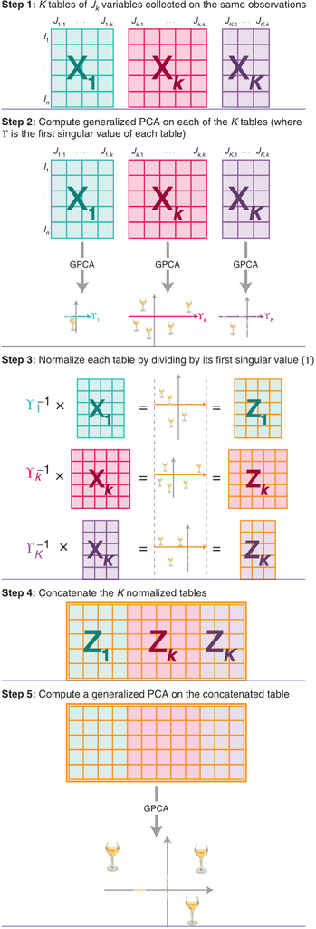

The general purpose of MFA is to bring out main factors of data variability in a balanced manner according to several sets of variables.

First, we normalize each of the individual data sets so that their first principal component has the same length.

After this, we can combine the data tables into a common representation of the observations, which we call the “compromise.”

The PCA of the compromise decomposes its variance into a new set of **orthonormal variables** ordered by the amount of variance that each component explains.

The coordinates of the observations on the components are called factor scores and can be used to plot maps of the observations.

In these plots, observations are represented as points such that the distances give us an idea of the similarities between them.

# Matrix Algebra and Terminology of MFA

- In the first step of MFA, each data table is expressed via its SVD as $\bf{X}_{[k]} = \bf{U}_{[k]}\bf{\Gamma}_{[k]}\bf{V}^\intercal_{[k]}$ with $\bf{U}^\intercal_{[k]}\bf{U}_{[k]} = \bf{V}^\intercal_{[k]}\bf{V}_{[k]} = \bf{I}$.
- From the SVD of each table we obtain its factor scores that are computed as $\bf{G}_{[k]} = \bf{U}_{[k]}\bf\Gamma_{[k]}$. The matrices ${\bf{U}_{[k]}}$ and ${\bf{V}_{[k]}}$ store the left and right singular vectors, respectively, of table $\bf{X}_{[k]}$, whose singular values are in the diagonal of diagonal matrix $\bf\Gamma_{[k]}$. The weight of table $k$, denoted $\alpha_{[k]}$, is the inverse of the first squared singular value.
- Weights are used to compute the GSVD of X under the constraints provided by $\bf{M}$ (masses for the observations), and $\bf{A}$ (squared singular value derived weights for the K tables). This GSVD ($\bf{X} = \bf{P}\Delta\bf{Q}^\intercal$ with $\bf{P}^\intercal\bf{M}\bf{P} = \bf{Q}^\intercal\bf{A}\bf{Q} = \bf{I}$) provides **factor scores** to describe the observations and **factor loadings** to describe the variables.
- We often write $\bf{X} = \bf{FQ}^\intercal$ with $\bf{F} = \bf{P}\Delta$, where $\bf{F}$ stores the factor scores and $\bf{Q}$ stores the loadings.

# The Wine Data Set Example

```
##     V1 V2 V3 V4 V5 V6 V1.1 V2.1 V3.1 V4.1 V7 V8 V1.2 V2.2 V3.2 V4.2 V9 V10
## NZ1  8  6  7  4  1  6    8    6    8    3  7  5    8    6    8    3  7   2
## NZ2  7  5  8  1  2  8    6    5    6    3  7  7    8    7    7    2  8   2
## NZ3  6  5  6  5  3  4    6    6    6    5  8  7    8    7    7    6  9   1
## NZ4  9  6  8  4  3  5    8    6    8    4  6  6    8    2    8    3  9   3
## FR1  2  2  2  8  7  3    2    3    1    7  4  3    3    4    3    6  4   6
## FR2  3  4  4  9  6  1    4    3    4    9  3  5    4    3    4    8  3   9
```